# The "conf" file (`conf/gitolite.conf`)

**Background**

Overview

Concepts, conventions, and terminology

Before you start...

**Basics**

Basic Administration

The conf file (`conf/gitolite.conf`)

the rc file (`~/.gitolite.rc`)

Your users' view of gitolite

Troubleshooting

**Advanced**

Special features/setups

Customising gitolite

**Extras**

Additional information/discussion

**Contributed docs**

You might recall from the basic administration page that this file is part of the gitolite-admin repo. You need to clone that repo, make and commit changes to this file, and push the commits back.

The `conf/gitolite.conf` file (often called just "the conf file" for short) is one of the two most important files in gitolite. It specifies repo names and access rules, as well as repo options of various kinds and git-config values.

Pretty much all day-to-day management, except managing users, happens from this file.

We'll use the following example to describe it's features. (A tip of the hat to Teemu Matilainen's gitolite vim-syntax file for the colors.)

```
# sample conf/gitolite.conf file

@staff              =   dilbert alice           # groups
@projects           =   foo bar

repo @projects baz                              # repos
    RW+             =   @staff                  # rules
    -       master  =   ashok
    RW              =   ashok
    R               =   wally

    option deny-rules           =   1           # options
    config hooks.emailprefix    = '[%GL_REPO] ' # git-config
```

# 1 basic syntax

As the example above shows, the syntax is fairly straightforward and simple.

- In general, everything is **space separated**; there are no commas, semicolons, etc., in the syntax.
- **Comments** are in the usual shell-ish style.
- **User names** and **repo names** are as simple as possible; they must start with an alphanumeric, but after that they can also contain `.`, `_`, or `-`. Usernames can optionally be followed by an `@` and a domainname containing at least one `.` (this allows you to use an email address as someone's username).
- **Group names** are like simple usernames (i.e., not email addresses) but start with an `@` sign.
- Reponames can contain `/` characters (this allows you to put your repos in a tree-structure for convenience).
- There are no continuation lines by default. You do not need them; the section on groups will tell you how you can break up large lists of names in a group definition into multiple lines. (But if you *must* have them, you can optionally enable them; look for "continuation-lines" in `~/.gitolite.rc`).

# 2 include files

Gitolite allows you to break up the configuration into multiple files and include them in the main file for convenience. For example:

```
include     "foo.conf"
```

will include the contents of the file "conf/foo.conf".

- You can also use a glob (`include "*.conf"`), or put your include files into subdirectories of "conf" (`include "foo/bar.conf"`), or both (`include "repos/*.conf"`).
- Included files are always searched from the gitolite-admin repo's "conf/" directory, unless you supplied an absolute path. (Note: in the interests of cloning the admin-repo sanely you should avoid absolute paths!)
- If you ended up recursing, files that have been already processed once are skipped, with a warning.
- It is not a fatal error for an include file to be missing. If it is a glob, you won't even get a warning.

Advanced users: `subconf`, a command that is very closely related to `include`, is documented here.

**Please note** that whenever you see "the `conf/gitolite.conf` file" or "the conf file" in gitolite documentation, it means the combined text after the include processing is done.

# 3 group definitions

You can group repos or users for convenience. The syntax is the same for both and does not distinguish; until you *use* the group name it could really be either.

Here's an example:

```
@developers     =   dilbert alice wally
```

Group definitions accumulate; this is the same as the above:

```
@developers     =   dilbert
@developers     =   alice
@developers     =   wally
```

You can use one group in another group definition; the values will be expanded immediately (meaning later additions will not appear in the second group).

```
@developers     =   dilbert alice
@interns        =   ashok
@staff          =   @interns @developers
@developers     =   wally

# wally is NOT part of @staff
```

Here's a very simple but complete example of using groups:

```
@developers     =   dilbert alice wally
@foss-repos     =   git gitolite

repo @foss-repos
    RW+         =   @developers
```

## 3.1 special group `@all`

`@all` is a special group name that is often convenient to use if you really mean "all repos" or "all users".

## 3.2 warnings on undefined groups

[output not shown]

Gitolite cannot truly catch undefined groups because the conf parser is 1-pass, and you're allowed to define a group *after* it is used, like so:

(v3.5.3+) However, in a simplistic attempt to help people tearing their hair out because of a typo, gitolite will warn if a group is not defined when it is used. So if you defined it later, either ignore the warning or move the definition up.

Note that these warnings do NOT appear if you're getting user group info from LDAP.

## 3.3 getting user group info from LDAP

Gitolite's groups are pretty convenient, but some organisations already have similar (or sufficient) information in their LDAP store.

Gitolite can tap into that information, with a little help. Write a program which, given a username, queries your LDAP store and returns a space-separated list of groups that the user is a member of. Then put the full path to this program in an rc variable called `GROUPLIST_PGM`, like so:

```
GROUPLIST_PGM           =>  '/home/git/bin/ldap-query-groups',
```

Now you can use those groupnames in access rules in gitolite, because the user is a member of those groups as well as any normal gitolite groups you may have added him to in the conf file.

Caution: your program must do its own logging if you want the audit trail of "why/how did this user get access to this repo at this time?" to resolve properly. Gitolite does not do any logging of the results of the queries because for people who don't need it that would be a huge waste.

# 4 access rules

Some of the pictures are thanks (*enormous* thanks!) to someone who contributed them but does not want to be named (go figure!). She even converted them to ditaa format when I asked; these are not as pretty as what she sent me originally but they're vim-editable in source form :-)

This section talks about how gitolite's access rules work. It's a **very important** section, and well worth spending some time on.

Gitolite's access rules are designed to be easy to use for common situations, such as some of the examples you saw earlier. However, they also pack a lot of power and flexibility.

Access rules decide whether a particular access is allowed or denied. An access is defined by four pieces of data: "reponame, username, operation, and ref". Each rule also has four similar pieces of data, and of course there are several rules -- some people have thousands! -- in the conf file. This section will try and explain how these rules are used to decide if a given operation is to be allowed or denied.

## 4.1 what does a rule look like?

[output not shown]

You've seen some simple rules so far, for example in the basic administration page. Here's a slightly more complex one, just for illustration.

A "repo" line names one or more repos, and is followed by one or more rule lines. All the rules from then till the next "repo" line apply to the repo(s) specified in the repo line -- in this example, the 'foo' and 'bar' repos.

Each rule line has a "permission" field, zero or more "refex"es, and one or more user or user group name after the equal sign.

The "repo" line can also have repo groups, as we have seen in the section on groups above. Also, it can have regular expressions that match multiple repos.

Before describing the various fields more formally, here's a description of what this specific rule list is saying:

- alice and the team leads can do whatever they want (i.e., push, rewind, or delete any branch or tag).
- dilbert and the dev team has these restrictions
  1. they can do anything to branches whose names start with "dev/"
  2. they can create or fast-forward push, but not rewind or delete, any branch except master
  3. they can create (but not update/delete) any tag except tags starting with "v" followed by a digit.
- managers can read the repo but they can't push anything.

More formally, a rule line has the following fields:

### 4.1.1 the permission field

The permission field gives the type of access this rule line permits. The most commonly used permissions are:

- R, to allow read operations only
- RW, to allow fast-forward push of a branch, or create new branch/tag
- RW+, to allow pretty much anything -- fast-forward, rewind or delete branches or tags
- `-` (the minus sign), to **deny** access.

There are also other, less commonly used, types of permissions.

### 4.1.2 the "refex" field

You cannot write rules for all possible branch and tag names (i.e., refs) that users will push. The only sensible way to do this is to use regular expressions instead.

A refex is a word I made up to mean "a regex that matches a ref".

In addition:

- If no refex is supplied, it defaults to `refs/.*`, for example in a rule like this:

  ```
  RW              =   alice
  ```

- A refex not starting with `refs/` (or `VREF/`) is assumed to start with `refs/heads/`. This means normal branches can be conveniently written like this:

  ```
  RW  master      =   alice
  # becomes 'refs/heads/master' internally
  ```

  while tags will need to be fully qualified

  ```
  RW  refs/tags/v[0-9]    =   bob
  ```

- A refex is implicitly anchored at the start, but not at the end. In regular expression lingo, a `^` is assumed at the start (but no `$` at the end is assumed). So a refex of `master` will match all these refs:

  ```
  refs/heads/master
  refs/heads/master1
  refs/heads/master2
  refs/heads/master/full
  ```

  More commonly, a refex of `refs/tags/v[0-9]` will match all versioned tags (i.e., not just `v1` but also `v12`, `v1.2`, `v12345`, etc.)

  If you want to restrict the match to just the one specific ref, add a $ at the end, for example:

  ```
  RW  master$     =   alice
  ```

You can also use virtual refs to perform extra checks and controls that you can't do with just the normal ref (like refs/heads/master) being pushed. The most common example is restricting pushes by dir/file name, but there are lots of other possibilities.

### 4.1.3 user/user group list

Like the repos on the repo line, you can have any number of user names and/or user group names on the rule line. (However, please note that there is no concept of regular expressions for user names).

**SECTION SUMMARY**: at this point you know that each rule basically specifies a repo, user, permission, and a "refex".

## 4.2 rule accumulation

*All* the rules for a repo need not be specified in one place. For example, you might see something like this, perhaps at the top or bottom of the conf file:

```
# managers should be able to read any repo
repo @all
    R   =   @managers
```

or perhaps this.

```
# anyone can clone open source repos
repo @FOSS
    R   =   @all
```

If a bunch of projects share some naming convention, you can specify any rules that are common to all of them by specifying the set of repos that are affected as a regular expression. Notice that the regex can be defined directly in the repo line, or it can be defined in a group and the *group* used in the repo line; it's all the same to gitolite.

```
repo FOSS/..*
    # ...rules for repos under FOSS/

@secret     =   secret/..* private/..*
repo @secret
    # ...rules for repos under secret/ and private/
```

Finally, although not very common, you can certainly do things like this. Note that the "other repos and rules" may indirectly include repo "foo" (for example it there were rules for "repo @all", or some other group that "foo" was a member of).

```
repo foo
    # ...some rules...

# ...other repos and rules...

repo foo
    # ...more rules for foo...
```

When access is being checked for an operation against a repo, **all the rules that pertain to that repo are collected, in the order they were seen in the conf file**.

Gitolite then **discards those rules that do *not* apply to the user whose access is being checked**. (A rule applies to a user if the user's name appears in the rule (after the equal sign), or if he is a member of any of the group names that appear in the rule.)

### 4.2.1 defining "user" and "repo"

To be very specific, when we speak of "user" and "repo" in rules,

- "user" means "user or a group that he/she is a member of", and
- "repo" means "repo, or a group that it is a member of, or a regex that matches it, or a group that contains a regex that matches it".

# 5 access control rule matching

Access control rule matching is pretty simple. From the previous section, you know what "permission", "refex", "user", and "repo" are. Here's how the rules are used to decide whether to allow or deny a request.

Access is checked once only for "read" operations, but twice for "write"s.

(Note that the `deny-rules` option, mentioned below, is explained in more detail in a later section.)

**Check #1**: the first check happens as soon as gitolite-shell receives control (from sshd or httpd). gitolite-shell will pass control to git-upload-pack or git-receive-pack only if this check succeeds.

- collect all the rules pertaining to this repo *and* this user
- ignore all the refexes; they don't apply to the first access check
- **if** the `deny-rules` option is **not** in effect for this repo, discard all the `-` (deny) rules
- look at the rules *in sequence*:
  - if you find a `-`, access is denied
  - for a "read" operation (clone, fetch, ...), if you find a rule containing `R`, access is allowed
  - for a "write" operation (push), if you find a rule containing `W`, access is allowed
  - if there are no more rules left, access is denied

**Check #2**: the second check only happens for "push" operations. It is invoked by `git-receive-pack` running the gitolite-installed `update` hook. If access is denied, the update hook fails, and git then aborts the push for this ref. (See `man githooks` for more.)

In the following description, we use the word `operation` instead of `W`, because the actual operation could be a plain, fast-forward, push (`W`) or a rewind/delete (`+`). Other, less commonly used, values are "C", "D", or "M"; see here.

- collect all the rules pertaining to this repo *and* this user
- discard all the rules where the refex does not match the ref (branch or tag) being pushed
- look at the rules *in sequence*:
  - if you find a `-`, access is denied
  - if you find a rule containing the operation you are performing, access is allowed
  - if there are no more rules left, access is denied

## 5.1 an example

Just to be clear, let's work out an example of what happens when dilbert tries to push a branch called "xyz".

We'll pretend the rule list looks like this.

```
# managers should be able to read any repo
repo @all
    R                       =   @managers

# ...other rules for other repos...

repo foo bar

    RW+                     =   alice @teamleads
    -   master              =   dilbert @devteam
    -   refs/tags/v[0-9]    =   dilbert @devteam
    RW+ dev/                =   dilbert @devteam
    RW                      =   dilbert @devteam
    R                       =   @managers
```

After adding a default refex and expanding the supplied ones (see the refex section earlier), this is what it looks like. We've added line numbers for convenience; we'll see why later.

```
 1 # managers should be able to read any repo
 2 repo @all
 3     R   refs/.*             =   @managers
 4
 5     # ...other rules for other repos...
 6
 7 repo foo bar
 8
 9     RW+ refs/.*             =   alice @teamleads
10     -   refs/heads/master   =   dilbert @devteam
11     -   refs/tags/v[0-9]    =   dilbert @devteam
12     RW+ refs/heads/dev/     =   dilbert @devteam
13     RW  refs/.*             =   dilbert @devteam
14     R   refs/.*             =   @managers
```

This represents a set of rules that are basically this:

```
repo    user        perm    ref                 (from line)

 foo     @managers  R        refs/.\*                3
 foo     alice      RW+      refs/.\*                9
 foo     @teamleads RW+      refs/.\*                9
 foo     dilbert    -        refs/heads/master       10
 foo     @devteam   -        refs/heads/master       10
 foo     dilbert    -        refs/tags/v[0-9]        11
 foo     @devteam   -        refs/tags/v[0-9]        11
 foo     dilbert    RW+      refs/heads/dev/         12
 foo     @devteam   RW+      refs/heads/dev/         12
 foo     dilbert    RW       refs/.\*                13
 foo     @devteam   RW       refs/.\*                13
 foo     @managers  R        refs/.\*                14
```

Which of these rules apply for dilbert? We'll assume he's not a team lead, as *that* would defeat the whole purpose of this example! We *know* he's not a manager, as that would defeat the whole purpose of the comic! Finally, we assume he's also not part of "@devteam", (otherwise why would you name him separately in all those lines?).

So we discard all those rules, which leaves us, for repo "foo" and user "dilbert":

```
perm    ref                 (from line)

-        refs/heads/master       10
-        refs/tags/v[0-9]        11
RW+      refs/heads/dev/         12
RW       refs/.\*                13
```

So what happens when dilbert tries to push a branch called "xyz"?

At check #1, the data gitolite has is that "oper" is "W" (and ref of course is unknown). We discard lines 10 and 11 (the `deny-rules` option is off by default, so we ignore `-` rules). Line 12 supplies a perm of "RW+", which contains "W" (the "oper") so access is allowed.

At check #2, the data gitolite has is that "oper" is "W" and ref is `refs/heads/xyz`. We discard the first three rules, since the ref does not match any of those refexes. That leaves just line 13.

If the push were a fast-forward push, the "oper" would be "W", and since it is contained in the perm for rule 13, access is allowed.

However, if he were to try a rewind-push, then the "oper" would be "+", which is not contained in "RW", it wouldn't match, then control would go back for the *next* rule, and since there aren't any more, access would be denied.

## 5.2 tracing the access control decision

(v3.6.1) Gitolite can help you trace this logic quickly and easily. Here's one example run, with the above rules. This one tests whether dilbert can push to repo foo (check #1). Note that the syntax for specifying an unknown ref in this command is 'any'.

```
$ gitolite access -s foo dilbert W any
legend:
    d => skipped deny rule due to ref unknown or 'any',
    r => skipped due to refex not matching,
    p => skipped due to perm (W, +, etc) not matching,
    D => explicitly denied,
    A => explicitly allowed,
    F => denied due to fallthru (no rules matched)

  d        gitolite.conf:10         -   refs/heads/master   =   dilbert @devteam
  d        gitolite.conf:11         -   refs/tags/v[0-9]    =   dilbert @devteam
  A        gitolite.conf:12         RW+ refs/heads/dev/     =   dilbert @devteam

refs/heads/dev/
```

Now see what happens when we try check #2 (we've omitted the legend in the output, since it's always the same):

```
$ gitolite access -s foo dilbert W xyz

  r        gitolite.conf:10         -   refs/heads/master   =   dilbert @devteam
  r        gitolite.conf:11         -   refs/tags/v[0-9]    =   dilbert @devteam
  r        gitolite.conf:12         RW+ refs/heads/dev/     =   dilbert @devteam
  A        gitolite.conf:13         RW  refs/.*             =   dilbert @devteam

refs/.*
```

And if you try a force push:

```
$ gitolite access -s foo dilbert + refs/heads/xyz

  r        gitolite.conf:10         -   refs/heads/master   =   dilbert @devteam
  r        gitolite.conf:11         -   refs/tags/v[0-9]    =   dilbert @devteam
  r        gitolite.conf:12         RW+ refs/heads/dev/     =   dilbert @devteam
  p        gitolite.conf:13         RW  refs/.*             =   dilbert @devteam
  F           (fallthru)

+ refs/heads/xyz foo dilbert DENIED by fallthru
```

I hope that was useful! Be sure you correlated the output of 'gitolite access -s' with the rule workflow pictures and corresponding descriptions to cement your understanding.

## 5.3 read access respecting deny rules

Note: This section has one or more forward references, referring to gitolite options, and the special users gitweb and daemon).

Normally, deny rules are ignored by access check #1 (the one that runs *before* git-upload-pack or git-receive-pack is called by gitolite-shell); they apply only to check #2 (the update hook check).

But sometimes you want this "pre-git" access check to respect deny rules; i.e., use the flow of check #2, not check #1. You tell gitolite to do this by setting the "deny-rules" option for the repo; when you do that, the flow of check #2 is used for both stages, before git *and* in the update hook.

## 5.4 example 1

Here's an example. Here, we have lots of repos, which should all be accessible by gitweb or daemon, so we want the convenience provided by lines 6 and 7 (we don't want to put line 7 in *each* repo). However, we also have some secret repos (maybe the gitolite-admin repo and some others that we will list), which we want to prevent gitweb or daemon from seeing.

How do we do that?

```
 1 @secret = gitolite-admin secret-repo/..*
 2 repo @secret
 3     -   =   gitweb daemon
 4
 5
 6 repo @all
 7     R   =   gitweb daemon
 8
 9 # ...other repos and rules...
10
```

The naive approach -- putting in a deny rule just for those repos -- doesn't work. In fact nothing else seems to work either; you'll have to replace the `@all` with an exhaustive list of *all repos other than the secret repos*.

That's... painful!

```
 1 @secret = gitolite-admin secret-repo/..*
 2 repo @secret
 3     -   =   gitweb daemon
 4     option deny-rules = 1
 5
 6 repo @all
 7     R   =   gitweb daemon
 8
 9 # ...other repos and rules...
10
```

What you really want is for that repo to always use check #2, even when it doesn't actually have a ref to test for.

This is done by adding *one* line, line 4 in this example. This sets a gitolite "option" that says you want "deny rules" to be applicable even for read access.

Once you do that, all you need to do is to ensure that the first rule encountered by these two "users" for those repos is a deny rule, so that it can take effect first. In this example, the placement of lines 2, 3 vis-a-vis lines 6, 7 matters -- don't switch them!

## 5.5 example 2

```
@open = git gitolite foss/..* [...]

repo @all
    -   =   gitweb daemon
    option deny-rules = 1

repo @open
    R   =   gitweb daemon
    option deny-rules = 0
```

In this example the "open" repos are fewer in number, so it is the opposite situation to the above in terms of our ability to enumerate all the repos.

To see why this works, you need to understand that for options and config lines, a later setting overrides earlier ones. So we set it to 1 for all repos, then selectively set it to 0 for some.

This means the "deny-rules" option applies to *all the repos except the "open" repos*, and so the first rule encountered by gitweb and daemon is a deny rule, so they are denied read access. The "open" repos, on the other hand, get the normal default behaviour, which is to ignore deny rules for read access, and thus they only see the "R" permission.

# 6 appendix 1: different types of write operations

Git supplies enough information to the update hook to be able to distinguish several types of writes.

The most common are:

- `RW` -- create a ref or fast-forward push a ref. No rewinds or deletes.
- `RW+` -- create, fast-forward push, rewind push, or delete a ref.

Sometimes you want to allow people to push, but not *create* a ref. Or rewind, but not *delete* a ref. The `C` and `D` qualifiers help here.

- If a rule specifies `RWC` or `RW+C`, then *rules that do NOT have the C qualifier will no longer permit **creating** a ref*.

  Please do not confuse this with the standalone `C` permission that allows someone to create a **repo**
- If a rule specifies `RWD` or `RW+D`, then *rules that do NOT have the D qualifier will no longer permit **deleting** a ref*.

Note: These two can be combined, so you can have `RWCD` and `RW+CD` as well.

One very rare need is to reject merge commits (a commit series that is not a straight line of commits). The `M` qualifier helps here:

- When a rule has `M` appended to the permissions, *rules that do NOT have it will reject a commit sequence that contains a merge commit* (i.e., they only accept a straight line series of commits).

## 6.1 summary of permissions

The full set of permissions, in regex syntax, is `-|R|RW+?C?D?M?`. This expands to one of `-`, `R`, `RW`, `RW+`, `RWC`, `RW+C`, `RWD`, `RW+D`, `RWCD`, or `RW+CD`, all but the first two optionally followed by an `M`.

# 7 appendix 2: gitolite access check flow

Here's lots more detail on the access check process, with flow diagrams.

When do the access checks happen and what are the four pieces of data (repo, user, operation, ref) in each case?

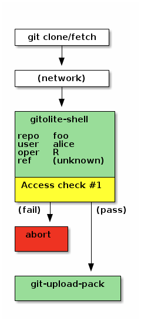

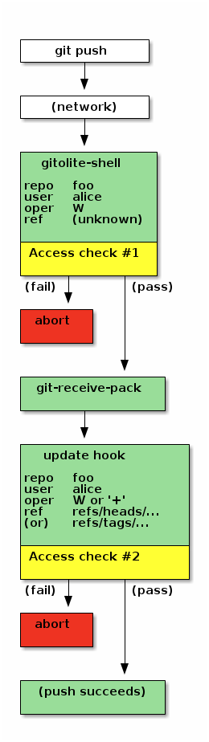

In these pictures the access checks are marked in yellow.

The picture on the left is for a read (git clone, fetch, ls-remote). There is only one access check for a read operation. If access is denied, the operation aborts. Otherwise, gitolite-shell invokes git-upload-pack.

Notice the information available to the access check. The "oper" (operation) is "R", indicating a read operation. The "ref" is listed as "unknown", although we could also call it "irrelevant"!

**Access check #1** proceeds with those 4 bits of information, and either passes or fails. If it passes, gitolite passes control to "git-upload-pack" and its job is done.

The flow for a push operation (the picture on the right) is *very* similar upto the first access check. The "oper" is "W" now, although the "ref" is still unknown. Even though this *is* a push, at this stage in the protocol nothing on the server knows what branch or tag or combination of them are coming down the wire, since we haven't executed git-receive-pack yet!

If it succeeds, gitolite passes control to "git-receive-pack", but its job is not done yet. *Git* will eventually invoke the update hook (see 'man githooks'). Gitolite has already grabbed this hook, which receives from git the ref name being pushed, as well as enough information to compute whether this push is a "fast-forward push" or a "rewind push". Based on this, gitolite sets the "oper" field to "W" or "+", respectively.

**Access check #2** proceeds with this information. The result is sent back to git-receive-pack (in the form of an exit code; again, see 'man githooks'), and the push fails or succeeds based on that.

## 7.1 putting it all together

At this point, we have the following pieces of information:

- A set of rules, each containing 4 pieces of data: repo, user, perm, refex. They are in the sequence they were found in the conf file.

  We discard all rules that do not apply to this repo and this user, which means our set of rules have only two fields: perm, refex.

  As a quick reminder, perm is one of R, RW, RW+, or `-`.
- Four elements that make up the access being attempted: repo, user, oper, ref.

  Again, as a reminder, the "oper" is **one letter**. For "check #1" it is either R or W, and for check #2 it can be W or +.

Note on permissions and "oper": there are other types of permissions, but for our discussion these are enough. The others are rare, and anyway it is easy to extrapolate to them.

With that background, here's the flow. The one on the left is for check #1 (ref is unknown) while the one on the right is for check #2 (ref is known). **Note** that the yellow (decision) boxes are numbered to help later discussion.

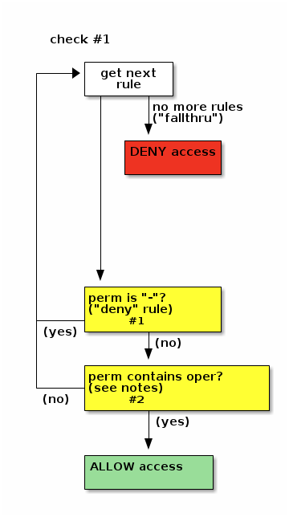

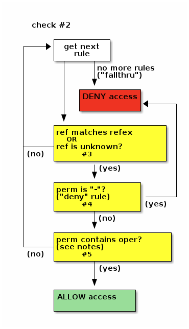

As you can see, deny rules are ignored by check #1 -- they're not tested in any way. For check #2, if there is a deny rule whose refex matched the ref, access is denied (as you'd expect).